# Alfredo_Credito

### Observações do Risk com relação as outras variaveis

```python
data["Risk"].value_counts()
```

```
Risk
0    700
1    300
Name: count, dtype: int64
```

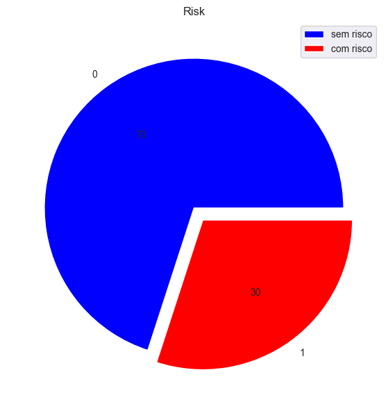

```python
labels=['0','1']
count= data['Risk'].value_counts()
plt.figure(figsize=(15,7))
plt.pie(count,labels=labels,autopct='%.0f',explode=(0,.1), colors=['b','r'])
plt.legend( ['sem risco','com risco'],loc =1)
plt.title('Risk')
plt.show()
```

**Observações do Risk com relação a Age**

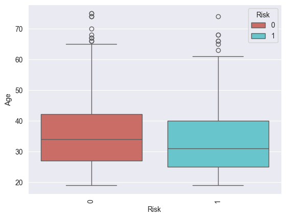

```python
sns.boxplot(data=data,x='Risk',y='Age',palette='hls',hue="Risk")
plt.xticks(rotation=90)
plt.show();
```

**Observações do Risk com relação a Duration**

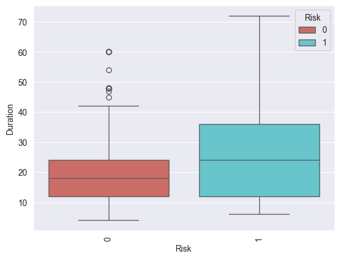

```python
sns.boxplot(data=data,x='Risk',y='Duration',palette='hls',hue="Risk")
plt.xticks(rotation=90)
plt.show();
```

**Observações do Risk com relação a Credit amount**

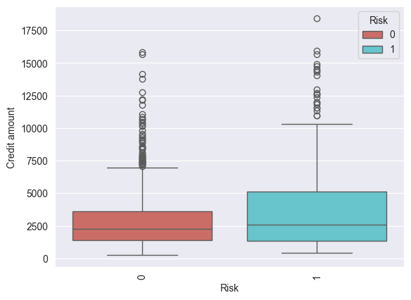

```python
sns.boxplot(data=data,x='Risk',y='Credit amount',palette='hls',hue="Risk")
plt.xticks(rotation=90)
plt.show();
```

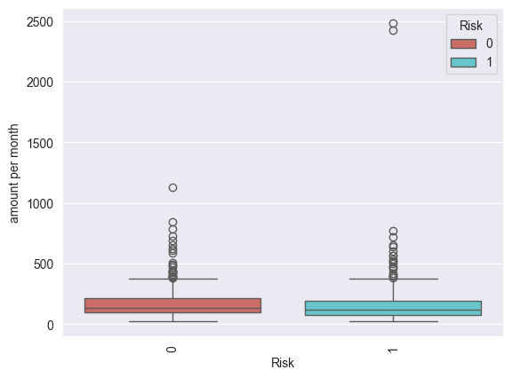

```python
sns.boxplot(data=data,x='Risk',y='amount per month',palette='hls',hue="Risk")
plt.xticks(rotation=90)
plt.show();
```

**Observações do Risk com relação a Sex**

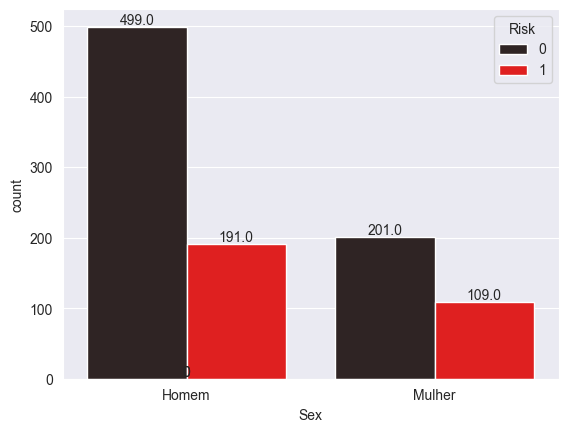

```python
df = data
ax = sns.countplot(data=data,x='Sex',hue= 'Risk', palette='dark:red')
for p in ax.patches:
    height = p.get_height()
    ax.annotate(f'{height}',
        (p.get_x() + p.get_width() / 2., height),ha='center', va='center',
        xytext=(0, 5), textcoords='offset points')
plt.show()
```

**Observações do Risk com relação a Job**

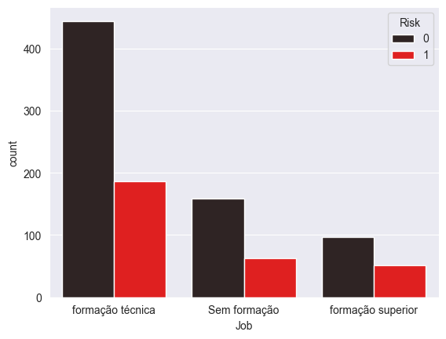

```python
sns.countplot(data=data,x='Job',hue= 'Risk', palette='dark:red')
plt.show()
```

**Observações do Risk com relação a Housing**

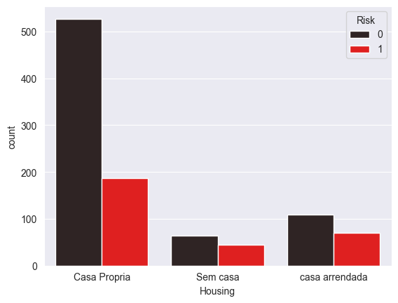

```python
sns.countplot(data=data,x='Housing',hue= 'Risk', palette='dark:red')
plt.show()
```

**Observações do Risk com relação a Saving accounts**

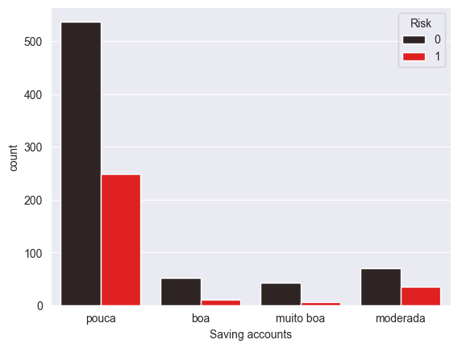

```python
sns.countplot(data=data,x='Saving accounts',hue= 'Risk', palette='dark:red')
plt.show()
```

**Observações do Risk com relação a Checking account**

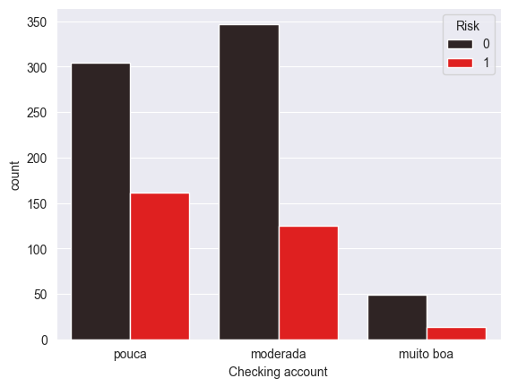

```python
sns.countplot(data=data,x='Checking account',hue= 'Risk',palette='dark:red')
plt.show()
```

**Observações do Risk com relação a Purpose**

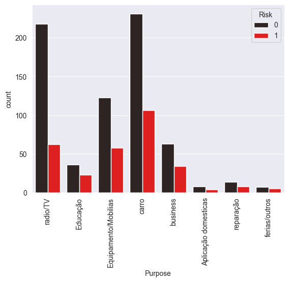

```python
sns.countplot(data=data,x='Purpose',hue= 'Risk',palette='dark:red')
plt.xticks(rotation=90)
plt.show()
```

**Conversão de dados categoricos ordinais em numericos**

```python
mapeamentos = {
    'Job': {'Sem formação': 1, 'formação técnica': 2, 'formação superior': 3},
    'Checking account': {'pouca': 1, 'moderada': 2, 'muito boa': 3},
    'Saving accounts': {'pouca': 1, 'moderada': 2, 'boa': 3,'muito boa': 4},
}
# Aplicar mapeamentos
for col in mapeamentos:
    data[col] = data[col].map(mapeamentos[col])
# Exibir o DataFrame transformado
data.head()
```

|  | Age | Sex | Job | Housing | Saving accounts | Checking account | Credit amount | Duration | Risk | Purpose | amount per month |
| --- | --- | --- | --- | --- | --- | --- | --- | --- | --- | --- | --- |
| 0 | 67 | Homem | 2 | Casa Propria | 1 | 1 | 1169 | 6 | 0 | radio/TV | 194.833333 |
| 1 | 22 | Mulher | 2 | Casa Propria | 1 | 2 | 5951 | 48 | 1 | radio/TV | 123.979167 |
| 2 | 49 | Homem | 1 | Casa Propria | 1 | 1 | 2096 | 12 | 0 | Educação | 174.666667 |
| 3 | 45 | Homem | 2 | Sem casa | 1 | 1 | 7882 | 42 | 0 | Equipamento/Mobilias | 187.666667 |
| 4 | 53 | Homem | 2 | Sem casa | 1 | 1 | 4870 | 24 | 1 | carro | 202.916667 |

```python
data.shape
```

```
(1000, 11)
```

**Normalizando os dados**

```python
from sklearn.preprocessing import MinMaxScaler
# Selecionar colunas numéricas
numeric_cols = data.select_dtypes(include=['number'])
# Criar o escalador
scaler = MinMaxScaler()
# Aplicar a normalização
numeric_cols_normalized = pd.DataFrame(scaler.fit_transform(numeric_cols),
                                       columns=numeric_cols.columns)
# Substituir as colunas numéricas no DataFrame original
data[numeric_cols.columns] = numeric_cols_normalized
data.head()
```

|  | Age | Sex | Job | Housing | Saving accounts | Checking account | Credit amount | Duration | Risk | Purpose | amount per month |
| --- | --- | --- | --- | --- | --- | --- | --- | --- | --- | --- | --- |
| 0 | 0.857143 | Homem | 0.5 | Casa Propria | 0.0 | 0.0 | 0.050567 | 0.029412 | 0.0 | radio/TV | 0.069461 |
| 1 | 0.053571 | Mulher | 0.5 | Casa Propria | 0.0 | 0.5 | 0.313690 | 0.647059 | 1.0 | radio/TV | 0.040642 |
| 2 | 0.535714 | Homem | 0.0 | Casa Propria | 0.0 | 0.0 | 0.101574 | 0.117647 | 0.0 | Educação | 0.061259 |
| 3 | 0.464286 | Homem | 0.5 | Sem casa | 0.0 | 0.0 | 0.419941 | 0.558824 | 0.0 | Equipamento/Mobilias | 0.066546 |
| 4 | 0.607143 | Homem | 0.5 | Sem casa | 0.0 | 0.0 | 0.254209 | 0.294118 | 1.0 | carro | 0.072749 |

```python
data.columns
```

```
Index(['Age', 'Sex', 'Job', 'Housing', 'Saving accounts', 'Checking account',
       'Credit amount', 'Duration', 'Risk', 'Purpose', 'amount per month'],
      dtype='object')
```

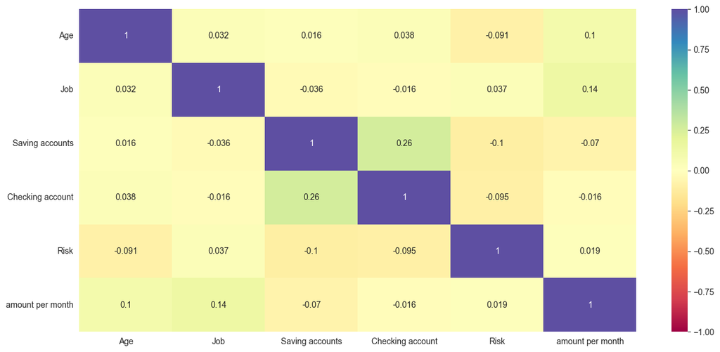

```python
correlation_matrix = data[['Age', 'Job', 'Saving accounts',
                        'Checking account','Risk', 'amount per month']].corr()
plt.figure(figsize=(15,7))
sns.heatmap(correlation_matrix,annot=True,cmap='Spectral',vmin=-1,vmax=1)
plt.show()
```

**Dividinho os dados em conjunto de treinamento e teste**

```python
X = data[['Age', 'Sex', 'Job', 'Housing', 'Saving accounts', 'Checking account',
        'Purpose', 'amount per month']]
Y = data['Risk']
# adicionando uma constante à variável X
X = add_constant(X)
# criando manequins
X = pd.get_dummies(X, drop_first=True, dtype = int)
# Dividindo dados em conjuntos de treinamento e teste
X_train, X_test, y_train, y_test = train_test_split(
    X, Y, test_size=0.30, random_state=42, stratify=Y)
```

```python
# Importando as bibliotecas necessarias
from sklearn.model_selection import train_test_split
from sklearn.metrics import accuracy_score, confusion_matrix, classification_report
from sklearn.linear_model import LogisticRegression
from sklearn.tree import DecisionTreeClassifier
from sklearn.ensemble import RandomForestClassifier, GradientBoostingClassifier
from sklearn.svm import SVC
from sklearn.neighbors import KNeighborsClassifier
from sklearn.naive_bayes import GaussianNB
from imblearn.under_sampling import RandomUnderSampler
from imblearn.under_sampling import RandomUnderSampler
```

#### Modelos de aprendizado de máquina

**Arvore de decisão**

```python
# Inicializar e treinar o modelo
tree_clf = DecisionTreeClassifier()
tree_clf.fit(X_train, y_train.values.ravel())
y_pred_tree = tree_clf.predict(X_test)
# Avaliar o modelo
print("Árvore de Decisão:")
print("Acurácia:", accuracy_score(y_test, y_pred_tree))
print("Matriz de Confusão:\n", confusion_matrix(y_test, y_pred_tree))
print("Relatório de Classificação:\n", classification_report(y_test,y_pred_tree))
```

```
Árvore de Decisão:
Acurácia: 0.6
Matriz de Confusão:
 [[143  67]
 [ 53  37]]
Relatório de Classificação:
               precision    recall  f1-score   support

         0.0       0.73      0.68      0.70       210
         1.0       0.36      0.41      0.38        90

    accuracy                           0.60       300
   macro avg       0.54      0.55      0.54       300
weighted avg       0.62      0.60      0.61       300
```

```python
# Definindo o modelo
dt = DecisionTreeClassifier()

# Definindo o grid de hiperparâmetros
param_grid = {
    'max_depth': [None, 10, 20, 30, 40, 50],
    'min_samples_split': [2, 5, 10],
    'min_samples_leaf': [1, 2, 4]
}
# Inicializar o Grid Search
grid_search = GridSearchCV(estimator=dt, param_grid=param_grid, cv=5, scoring='accuracy')

# Treinar o modelo
grid_search.fit(X_train, y_train.values.ravel())

# Obter os melhores parâmetros e o melhor modelo
best_params_dt= grid_search.best_params_
best_dt = grid_search.best_estimator_

# Fazer previsões
y_pred_dt = best_dt.predict(X_test)

# Avaliar o modelo
print("Arvore de decisão:")
print("Melhores Parâmetros:", best_params_dt)
```

```
Arvore de decisão:
Melhores Parâmetros: {'max_depth': 10, 'min_samples_leaf': 1, 'min_samples_split': 10}
```

```python
# Inicializar e treinar o modelo
tree_clf = DecisionTreeClassifier(class_weight='balanced',min_samples_split=10,
max_depth= 10, min_samples_leaf= 1)
tree_clf.fit(X_train, y_train.values.ravel())
y_pred_tree = tree_clf.predict(X_test)
# Avaliar o modelo
print("Árvore de Decisão:")
print("Acurácia:", accuracy_score(y_test, y_pred_tree))
print("Matriz de Confusão:\n", confusion_matrix(y_test, y_pred_tree))
print("Relatório de Classificação:\n",classification_report(y_test,y_pred_tree))
```

```
Árvore de Decisão:
Acurácia: 0.5533333333333333
Matriz de Confusão:
 [[116  94]
 [ 40  50]]
Relatório de Classificação:
               precision    recall  f1-score   support

         0.0       0.74      0.55      0.63       210
         1.0       0.35      0.56      0.43        90

    accuracy                           0.55       300
   macro avg       0.55      0.55      0.53       300
weighted avg       0.62      0.55      0.57       300
```

**Floresta aleatoria**

```python
# Inicializar e treinar o modelo
rf_clf = RandomForestClassifier()
rf_clf.fit(X_train, y_train.values.ravel())
y_pred_rf = rf_clf.predict(X_test)
# Avaliar o modelo
print("Random Forest:")
print("Acurácia:", accuracy_score(y_test, y_pred_rf))
print("Matriz de Confusão:\n", confusion_matrix(y_test, y_pred_rf))
print("Relatório de Classificação:\n", classification_report(y_test, y_pred_rf))
```

```
Random Forest:
Acurácia: 0.68
Matriz de Confusão:
 [[186  24]
 [ 72  18]]
Relatório de Classificação:
               precision    recall  f1-score   support

         0.0       0.72      0.89      0.79       210
         1.0       0.43      0.20      0.27        90

    accuracy                           0.68       300
   macro avg       0.57      0.54      0.53       300
weighted avg       0.63      0.68      0.64       300
```

```python
# Definir o modelo
rf_clf = RandomForestClassifier()

# Definir os parâmetros para o Grid Search
param_grid_rf = {
    'n_estimators': [50, 100, 200],
    'max_depth': [None, 10, 20, 30],
    'min_samples_split': [2, 5, 10],
    'min_samples_leaf': [1, 2, 4]
}
# Inicializar o Grid Search
grid_search_rf = GridSearchCV(rf_clf, param_grid_rf, cv=5, scoring='accuracy', n_jobs=-1)
# Treinar o modelo
grid_search_rf.fit(X_train, y_train.values.ravel())
# Obter os melhores parâmetros e o melhor modelo
best_params_rf = grid_search_rf.best_params_
best_rf = grid_search_rf.best_estimator_
# Fazer previsões
y_pred_rf = best_rf.predict(X_test)
# Avaliar o modelo
print("Random Forest:")
print("Melhores Parâmetros:", best_params_rf)
```

```
Random Forest:
Melhores Parâmetros: {'max_depth': None, 'min_samples_leaf': 4, 'min_samples_split': 5, 'n_estimators': 50}
```

```python
# Inicializar o under-sampler
rus = RandomUnderSampler(sampling_strategy='majority')
X_resampled, y_resampled = rus.fit_resample(X_train, y_train)
model = RandomForestClassifier(class_weight='balanced',
    min_samples_leaf= 1, min_samples_split= 5, n_estimators= 100, max_depth= 10)
model.fit(X_resampled, y_resampled)
y_pred = model.predict(X_test)
print("Random Forest:")
print("Acurácia:", accuracy_score(y_test, y_pred))
print("Matriz de Confusão:\n", confusion_matrix(y_test, y_pred))
print("Relatório de Classificação:\n", classification_report(y_test, y_pred))
```

```
Random Forest:
Acurácia: 0.5533333333333333
Matriz de Confusão:
 [[107 103]
 [ 31  59]]
Relatório de Classificação:
               precision    recall  f1-score   support

         0.0       0.78      0.51      0.61       210
         1.0       0.36      0.66      0.47        90

    accuracy                           0.55       300
   macro avg       0.57      0.58      0.54       300
weighted avg       0.65      0.55      0.57       300
```

**Regressão logistica**

```python
# Inicializar e treinar o modelo
log_reg = LogisticRegression()
log_reg.fit(X_train, y_train.values.ravel())
# Fazer previsões
y_pred_log = log_reg.predict(X_test)
# Avaliar o modelo
print("Regressão Logística:")
print("Acurácia:", accuracy_score(y_test, y_pred_log))
print("Matriz de Confusão:\n", confusion_matrix(y_test, y_pred_log))
print("Relatório de Classificação:\n",classification_report(y_test, y_pred_log))
```

```
Regressão Logística:
Acurácia: 0.72
Matriz de Confusão:
 [[203   7]
 [ 77  13]]
Relatório de Classificação:
               precision    recall  f1-score   support

         0.0       0.72      0.97      0.83       210
         1.0       0.65      0.14      0.24        90

    accuracy                           0.72       300
   macro avg       0.69      0.56      0.53       300
weighted avg       0.70      0.72      0.65       300
```

```python
# Definir o modelo
log_reg = LogisticRegression()

# Definir os parâmetros para o Grid Search
param_grid_log_reg = {
    'C': [0.01, 0.1, 1, 10, 100],
    'solver': ['liblinear', 'saga'],
    'max_iter':[5,10,100,1000]}
# Inicializar o Grid Search
grid_search_log_reg = GridSearchCV(log_reg, param_grid_log_reg, cv=5, scoring='accuracy', n_jobs=-1)

# Treinar o modelo
grid_search_log_reg.fit(X_train, y_train.values.ravel())

# Obter os melhores parâmetros e o melhor modelo
best_params_log_reg = grid_search_log_reg.best_params_
best_log_reg = grid_search_log_reg.best_estimator_

# Fazer previsões
y_pred_log = best_log_reg.predict(X_test)

# Avaliar o modelo
print("Regressão Logística:")
print("Melhores Parâmetros:", best_params_log_reg)
```

```
Regressão Logística:
Melhores Parâmetros: {'C': 0.01, 'max_iter': 5, 'solver': 'liblinear'}
```

```python
# Inicializar o under-sampler
rus = RandomUnderSampler(sampling_strategy='majority')
X_resampled, y_resampled = rus.fit_resample(X_train, y_train)
model = LogisticRegression(class_weight='balanced',C = 0.01,
max_iter=5,solver='liblinear')
model.fit(X_resampled, y_resampled)
y_pred = model.predict(X_test)
# Avaliar o modelo
print("Regressão Logística:")
print("Acurácia:", accuracy_score(y_test, y_pred))
print("Matriz de Confusão:\n", confusion_matrix(y_test, y_pred))
print("Relatório de Classificação:\n", classification_report(y_test, y_pred))
```

```
Regressão Logística:
Acurácia: 0.5666666666666667
Matriz de Confusão:
 [[117  93]
 [ 37  53]]
Relatório de Classificação:
               precision    recall  f1-score   support

         0.0       0.76      0.56      0.64       210
         1.0       0.36      0.59      0.45        90

    accuracy                           0.57       300
   macro avg       0.56      0.57      0.55       300
weighted avg       0.64      0.57      0.58       300
```